# create own Data Frame

## Background for this activity

This activity is focused on creating and using data frames in `R`. A data frame is a collection of columns containing data, similar to a spreadsheet or SQL table. Data frames are one of the basic tools you will use to work with data in `R`. And you can create data frames from different data sources.

Wherever data comes from, you will almost always want to store it in a data frame object to work with it. Now,you can start creating and exploring data frames with the code chunks in the RMD space. To interact with thecode chunk, click the green arrow in the top-right corner of the chunk. The executed code will appear in theRMD space and your console.

## Step 1: Load packages

```r
library(tidyverse)
```

## Step 2: Create data frame

```r
names <- c("rama","shiva","raju","ravi","bala","jhonson","david","kavien")
```

```r
age <- c(23,27,21,33,32,27,27,28)
```

```r
occupationa_lStatus <- c("financial manager","cheif executive","General and Operations Managers","Sales Managers","cheif executive","Industrial Production Managers","financial manager","General and Operations Managers")
```

```r
people <- data.frame(names, age,occupationa_lStatus)
```

```r
people
```

```
##     names age             occupationa_lStatus
## 1    rama  23               financial manager
## 2   shiva  27                 cheif executive
## 3    raju  21 General and Operations Managers
## 4    ravi  33                  Sales Managers
## 5    bala  32                 cheif executive
## 6 jhonson  27  Industrial Production Managers
## 7   david  27               financial manager
## 8  kavien  28 General and Operations Managers
```

## Step 3: inspect the data frame

Now that you have this data frame, you can use some different functions to inspect it. One common function you can use to preview the data is the head() function, which returns the columns and the first several rows of data. You can check out how the head() function works by running the chunk below :

```r
head(people)
```

```
##     names age             occupationa_lStatus
## 1    rama  23               financial manager
## 2   shiva  27                 cheif executive
## 3    raju  21 General and Operations Managers
## 4    ravi  33                  Sales Managers
## 5    bala  32                 cheif executive
## 6 jhonson  27  Industrial Production Managers
```

In addition to head(), there are a number of other useful functions to summarize or preview your data. For example, the str() and glimpse() functions will both provide summaries of each column in your data arranged horizontally. You can check out these two functions in action by running the code chunks below :

```r
glimpse(people)
```

```
## Rows: 8
## Columns: 3
## $ names               <chr> "rama", "shiva", "raju", "ravi", "bala", "jhonson"…
## $ age                 <dbl> 23, 27, 21, 33, 32, 27, 27, 28
## $ occupationa_lStatus <chr> "financial manager", "cheif executive", "General a…
```

```r
str(people)
```

```
## 'data.frame':    8 obs. of  3 variables:
##  $ names              : chr  "rama" "shiva" "raju" "ravi" ...
##  $ age                : num  23 27 21 33 32 27 27 28
##  $ occupationa_lStatus: chr  "financial manager" "cheif executive" "General and Operations Managers" "Sales Managers" ...
```

You can also use colnames() to get a list the column names in your data set. Run the code chunk below to check out this function:

```r
colnames(people)
```

```
## [1] "names"               "age"                 "occupationa_lStatus"
```

Now that you have a data frame, you can work with it using all of the tools in R. For example, you could use mutate() if you wanted to create a new variable that would capture each person’s age in twenty years. The code chunk below creates that new variable :

```r
mutate(people, age_in_20 = age + 20)
```

```
##     names age             occupationa_lStatus age_in_20
## 1    rama  23               financial manager        43
## 2   shiva  27                 cheif executive        47
## 3    raju  21 General and Operations Managers        41
## 4    ravi  33                  Sales Managers        53
## 5    bala  32                 cheif executive        52
## 6 jhonson  27  Industrial Production Managers        47
## 7   david  27               financial manager        47
## 8  kavien  28 General and Operations Managers        48
```

## compare age and occupations

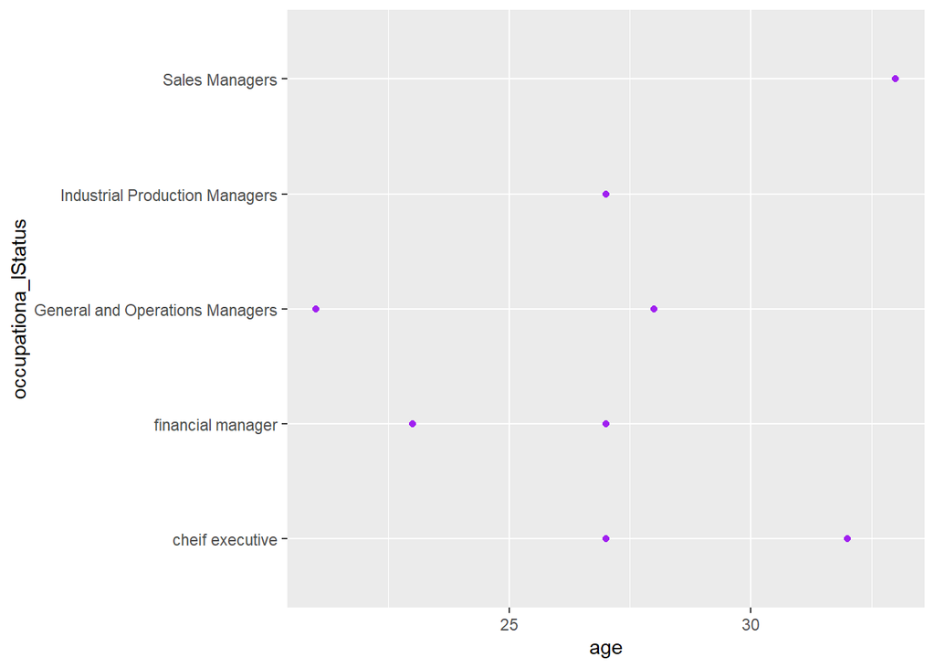

```r
ggplot(data=people,aes(x=age,y=occupationa_lStatus))+ geom_point(color=
"purple"
)
```

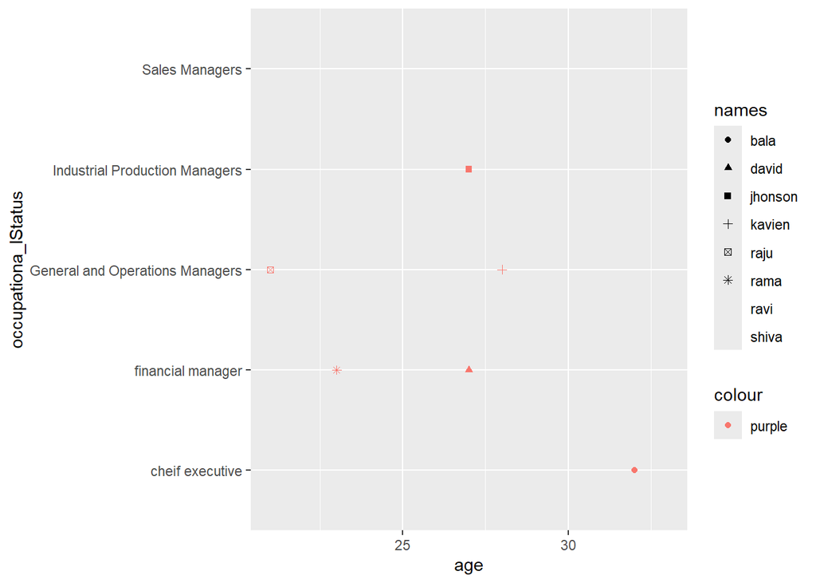

```r
ggplot(data=people,aes(x=age,y=occupationa_lStatus))+ geom_point(aes(color="purple",shape=names))
```

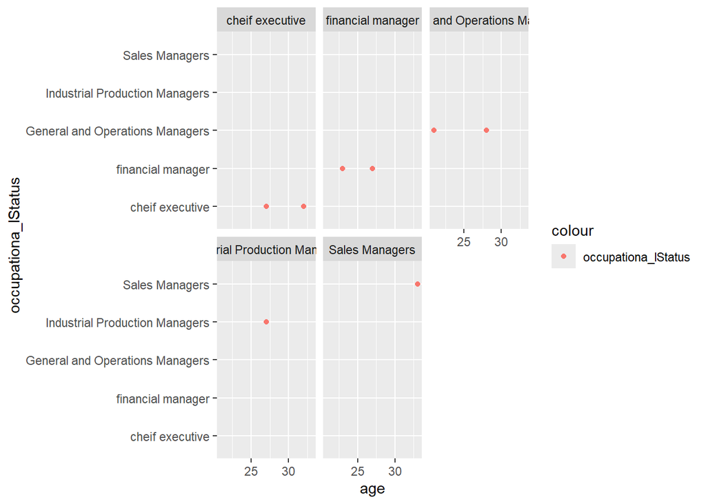

```r
ggplot(data=people,aes(x=age,y=occupationa_lStatus))+ geom_point(aes(color="occupationa_lStatus")) + facet_wrap(~occupationa_lStatus)
```

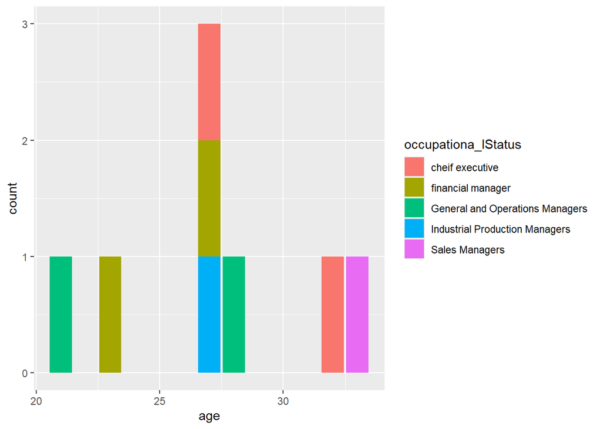

```r
ggplot(data = people) + geom_bar(mapping = aes(x = age, fill = occupationa_lStatus))
```

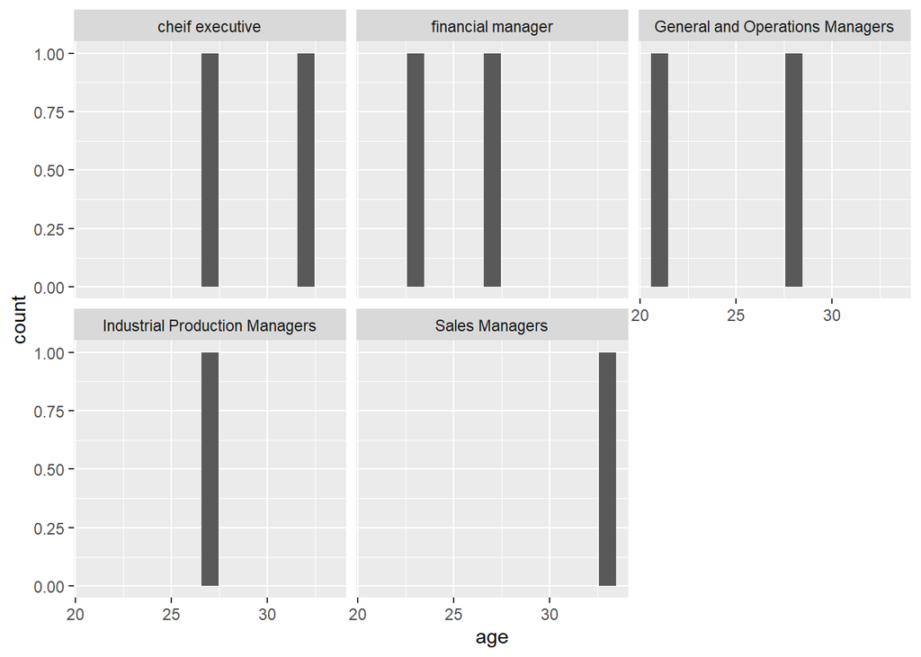

```r
ggplot(data = people) + geom_bar(mapping = aes(x = age)) + facet_wrap(~occupationa_lStatus)
```

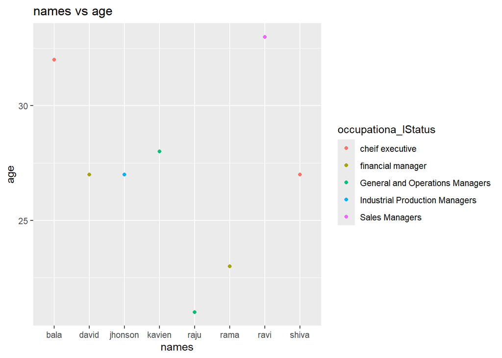

```r
ggplot(data = people, aes(x = names, y =age , col = occupationa_lStatus)) +
  geom_point() +
  labs(title = "names vs age",
       x = "names",
       y = "age")
```

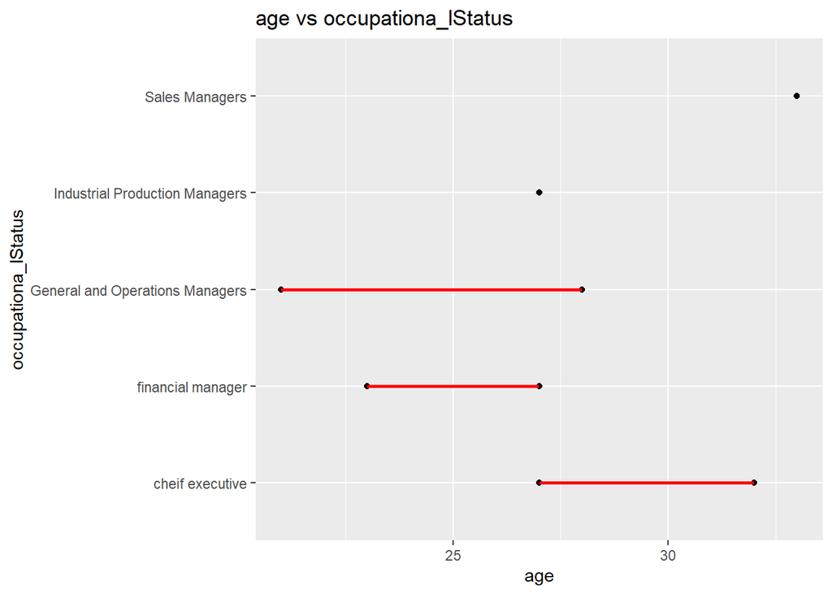

```r
ggplot(data = people, aes(x = age, y = occupationa_lStatus)) +
  geom_point() +
  stat_smooth(method = lm, col = "red") +
  labs(title = "age vs occupationa_lStatus")
```

```r
hist_plot_mpg <- ggplot(people, aes(x = age)) +
  geom_histogram(binwidth = 2, fill = "blue", color = "white") +
  labs(title = "Histogram: Miles per Gallon", x = "age", y = "occupationa_lStatus")
```

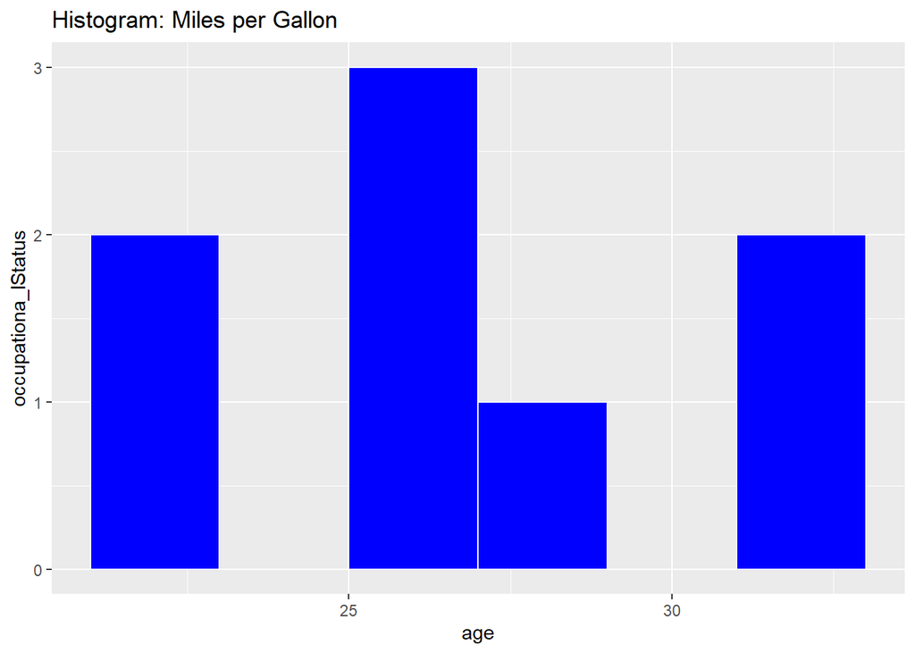

```r
hist_plot_mpg
```

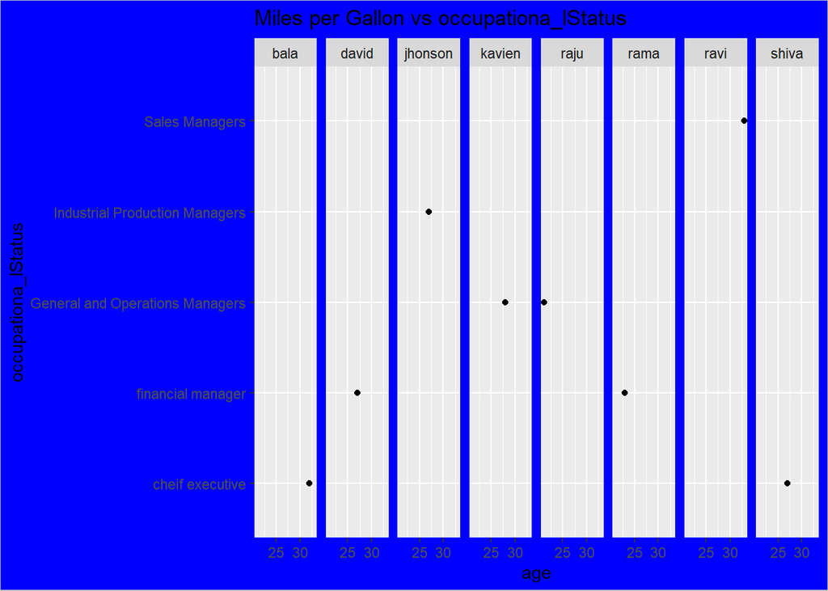

```r
ggplot(data = people, aes(x = age, y = occupationa_lStatus)) +
  geom_point() +
  facet_grid(. ~ names) +
  theme(plot.background = element_rect(fill = "blue", colour = "gray")) +
  labs(title = "Miles per Gallon vs occupationa_lStatus")
```

## Activity Wrap Up

we can practice these skills by modifying the code chunks in the rmd file, or use this code as starting point in your own project console. Now that your stakeholder has had a chance to review these plots,they are interested in adding annotations they can use to explain the data in a presentation.